# Problem Set #3

## Question 2: Small Multiples

Now, let’s consider the case of a multivariate time series where you have time series of multiple people and want to get a esnse of general patterns, missingness, etc.

1. Plot a small multiples plot of 20 people (hint: use the `sample()` function).
2. Make sure to:
- Use `facet_wrap()`
- Use `geom_area()` to show relative differences in levels
- Use whatever combination of points and lines makes sense for your density of data
- Add labels and titles as appropriate

If you’re using provided data, use the skeleton code below to get the observations for 20 people with at least 15 observations.

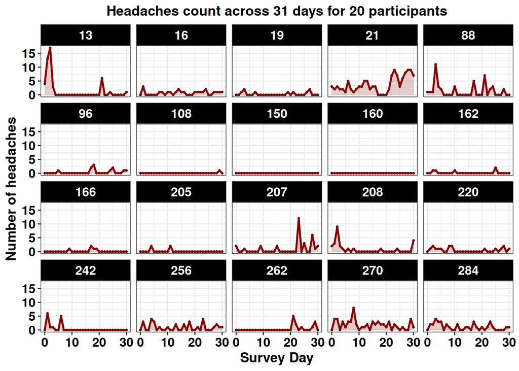

```r
set.seed(555)
# ps3_df %>%
#   group_by(SID) %>%
#   filter(n() > 15) %>%
#   ungroup() %>%
#   filter(SID %in% sample(unique(.$SID), 20))
## Your code here ##

pcs %>%
  dplyr::with_groups(c(subject_id, survey_day),
                     summarise,
                     head_d = sum(head)) |>  # number of headaches per day
  dplyr::with_groups(subject_id,
                     dplyr::filter,
                     n() > 30) %>%
  dplyr::filter(subject_id %in% sample(unique(.$subject_id), 20)) |>
  ggplot(aes(x = survey_day, y = head_d)) +
  geom_point(size = .5) +
  geom_line(color = "red4", size = .9) +
  geom_area(fill = "red4", alpha = .2) +
  facet_wrap(~subject_id, nrow = 4) +
  my_theme() +
  labs(x = "Survey Day",
       y = "Number of headaches",
       title = "Headaches count across 31 days for 20 participants")
```

# Part 2: Visualizing Uncertainty

Next, you’ll practice Week 6 skills, specifically how to visualize uncertainty. To give you a chance to also practice smoothing and model predictions from time series, Q2 will also have you make predictions across a time series.

## Question 1: Visualizing point estimates

For this question, I recommend using the same model that you used in ps2. For those using provided data, that means you’ll use this data:

```r
# load(url("https://github.com/emoriebeck/psc290-data-viz-2022/blob/main/04-week4-associations/04-data/week4-data.RData?raw=true"))
# pred_data
```

And this model:

```r
# m_fun <- function(x){
#   x <- x %>% mutate(education = factor(as.numeric(as.character(education))))
#   glm(physhlthevnt ~ gender + education, data = x, family = binomial(link = "logit"))
# }
# nested_mods <- pred_data %>%
#   select(study, SID, p_value, gender, smokes, education, physhlthevnt) %>%
#   filter(physhlthevnt %in% c(1,0)) %>%
#   mutate(gender = as.numeric(as.character(gender))) %>%
#   group_by(study) %>%
#   nest() %>%
#   ungroup() %>%
#   mutate(m = map(data, m_fun),
#          tidy = map(m, ~tidy(., conf.int = T)),
#          df = map_dbl(m, df.residual))

pcs_mod <- readRDS("../02-ps2/fit_nb.rds")
tidy_mod <- broom.mixed::tidy(pcs_mod, exponentiate=TRUE)
```

```r
fit_nb <- brm(head ~ concussion * survey_day + (1 | subject_id),
              data = data, family = zero_inflated_negbinomial(),
              iter = 2000, chains = 4, cores = 4)
```

1. Plot the point estimates for all estimates using one of the functions we discussed in class (e.g., `stat_halfeye()`)

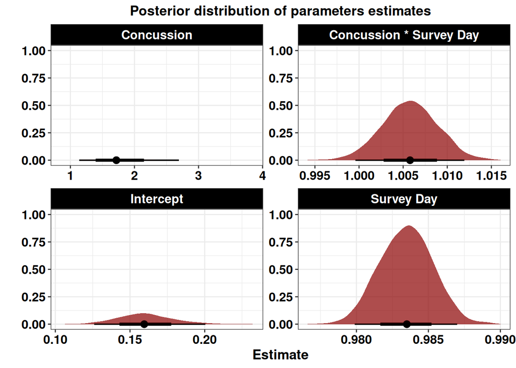

```r
## Your code here ##
library(tidybayes)
posterior_samples <- pcs_mod |>
  spread_draws(
    b_Intercept, b_concussion, b_survey_day, `b_concussion:survey_day`
               )  |>
  pivot_longer(cols = starts_with("b_"),
               names_to = "parameter", values_to = "estimate") |>
  mutate(estimate = exp(estimate)) |>
  mutate(parameter = case_when(
    parameter == "b_Intercept" ~ "Intercept",
    parameter == "b_concussion" ~ "Concussion",
    parameter == "b_survey_day" ~ "Survey Day",
    parameter == "b_concussion:survey_day" ~ "Concussion * Survey Day",
  ))

# Plot
posterior_samples |>
  ggplot( aes(x = estimate)) +
  stat_pointinterval() +
  stat_halfeye(fill = "red4", alpha = .7) +
  # using facets because plotting all in the same canvas makes it hard
  # to properly visualize the distributions
  facet_wrap(~parameter, scales = "free") +
  scale_y_continuous(limits = 0:1) +
  my_theme() +
  labs(title = "Posterior distribution of parameters estimates",
       x = "Estimate", y = "")
```

```r
# Idk why the Concussion density curve is not showing.
# When I plot it individually it shows up normally
```

2. Plot the marginal means for a categorical variable (use the provided data set if your model doesn’t have one).

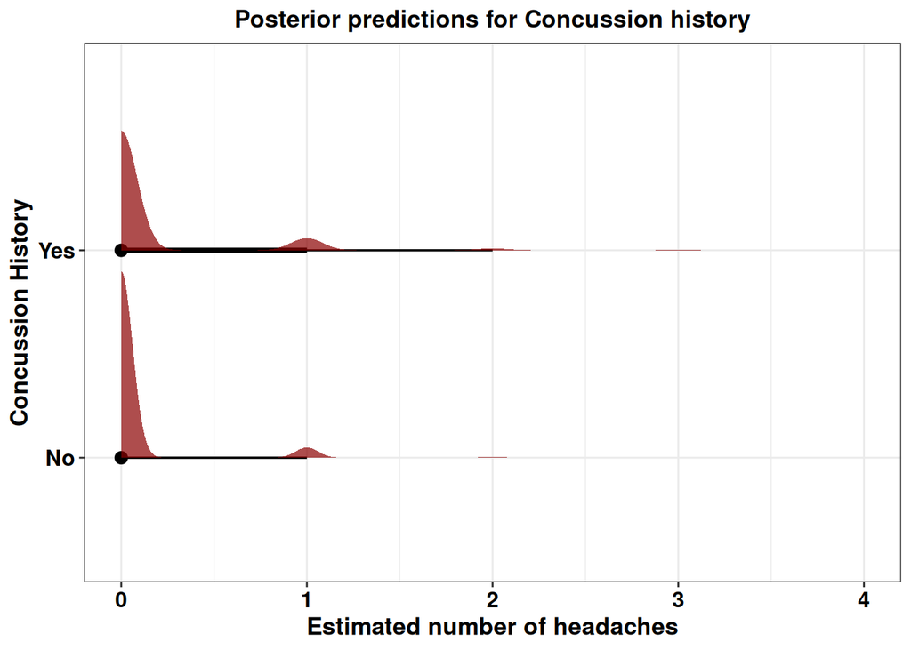

```r
# q2_1_pred_fun <- function(m){
#   m$data %>%
#     data_grid(education) %>%
#     mutate(gender = mean(m$data$gender)) %>%
#     augment(m, newdata = ., se_fit = T)
# }
#
# nested_mods <- nested_mods %>%
#   mutate(pred = map(m, q2_1_pred_fun),
#          df = map_dbl(m, df.residual))
## Your code here ##

pcs |>
  data_grid(concussion, survey_day = median(survey_day, na.rm = TRUE)) |>
  add_predicted_draws(pcs_mod, re.form = NA) |>
  dplyr::mutate(concussion = haven::as_factor(concussion)) |>
  ggplot(aes(y = concussion, x = .prediction)) +
  stat_pointinterval(.width = c(.66, .95)) +
  stat_slab(fill = "red4", alpha = .7) +
  my_theme() +
  labs(title = "Posterior predictions for Concussion history",
       x = "Estimated number of headaches", y = "Concussion History")
```

## Question 2: Plotting smoothed trajectories

In class, we talked about multiple geoms / methods for plotting the uncertainty around trajectories:

- `geom_line()` (across bootstrapped samples)
- `geom_lineribbon()` (across bootstrapped samples)

Below, I give you code using the provided data from Part 1 to get bootstrapped samples. If you want to use your own data, you just need to modify the model and the `pred_fx_fun()`. `predIntlme4()` should be a general function that should work with any lme4 model.

```r
m2 <- lmer(satHealth ~ 1 + age + age:gender + (1 + age | SID), data = ps3_df)
tidy(m2)
```

```r
predIntlme4 <- function(m, mod_frame, ref){
  ## get bootstrapped estimates
  b <- bootMer(
    m
    , FUN = function(x) lme4:::predict.merMod(
      x
      , newdata = mod_frame
      , re.form = ref
      )
    , nsim = 100 # do not use 100 in practice, please
    , parallel = "multicore"
    , ncpus = 16
    )

  ## get long form bootstrapped draws
  b_df <- bind_cols(
    mod_frame
    , t(b$t) %>%
    data.frame()
  ) %>%
    pivot_longer(
       cols = -one_of(colnames(m@frame))
      , names_to = "boot"
      , values_to = "pred"
    )
  return(list(boot = b, b_df = b_df))
}
```

```r
pred_fx_fun <- function(m){
  mod_frame <- m@frame %>%
    group_by(gender) %>%
    data_grid(age = seq_range(age, n = 101))
  boot <- predIntlme4(m = m, mod_frame = mod_frame, ref = NA)
}

boot2 <- pred_fx_fun(m2)
b_df2 <- boot2$b_df
b2 <- boot2$boot
```

Choose two of the methods we discussed in class and plot the trajectories (or trajectory if you don’t have a moderator) and plot the bands around the trajectory.

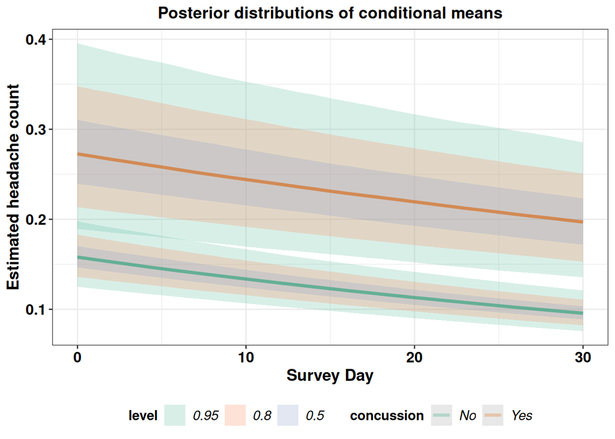

```r
## Your code here ##

pred_pcs <- pcs |>
  group_by(concussion) |>
  data_grid(survey_day) |>
  add_epred_draws(pcs_mod, re.form = NA) |>
  dplyr::mutate(concussion = haven::as_factor(concussion))

pred_pcs |>
  ggplot(aes( x = survey_day, y = .epred, color = concussion)) +
   stat_lineribbon(aes(y = .epred), .width = c(.95, .80, .50), alpha = 1/4) +
  scale_fill_brewer(palette = "Set2") +
  scale_color_brewer(palette = "Dark2") +
  my_theme() +
  labs(x = "Survey Day", y = "Estimated headache count",
       title = "Posterior distributions of conditional means")
```

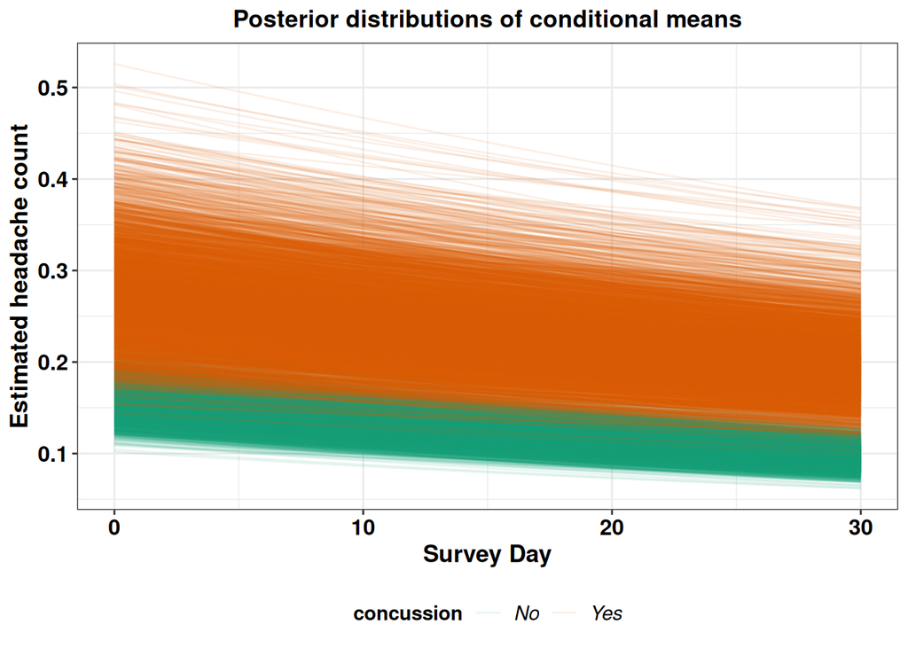

```r
## Your code here ##
pred_pcs |>
  ggplot(aes ( x = survey_day, y = .epred, color = concussion)) +
  geom_line(aes(y = .epred, group = paste(concussion, .draw)), alpha = .1) +
  scale_color_brewer(palette = "Dark2") +
  my_theme() +
  labs(x = "Survey Day", y = "Estimated headache count",
       title = "Posterior distributions of conditional means")
```

# Render to html and submit problem set

**Render to html** by clicking the “Render” button near the top of your RStudio window (icon with blue arrow)

- Go to the Canvas –> Assignments –> Problem Set 3
- Submit both .qmd and .html files
- Use this naming convention “lastname_firstname_ps#” for your .qmd and html files (e.g. beck_emorie_ps3.qmd & beck_emorie_ps3.html)